# Michael Ellsworth - Assignment 1

# Further explore the dataset “api”

The dataset “api” in package “survey” contains the academic performance index for year 1999 (api99) and 2000 (api00). To import the data, you need to attach the package “survey”.

*Goal*: **estimate the population average as well as the standard deviation of the estimate**.

## Population level

### Question 1

Calculate the population mean

```r
pop_mean <- mean(MYDATA$api00)
pop_mean
```

```
[1] 664.6981
```

## Equal-size cluster sampling

### Question 2

Apply one-stage cluster sampling to estimate the population mean (**n=3**), calculate its estimated standard deviation (refer to the formula in lecture notes), **using L1$\sim$L10 as clusters**.

```r
# Define number of clusters sampled, number of clusters total and size of clusters
n_cluster <- 3
N_cluster <- 10
M_cluster <- nrow(MYDATA)/N_cluster
# Create a vector of cluster names to sample from
clusters <- paste0("L", seq(1, 10))
# Sample from the cluster name vectors n times
cluster_sample <- sample(clusters, n_cluster)
# Filter the MYDATA table to include only the clusters from cluster_sample
MYDATA_cluster_sample <- MYDATA %>%
  filter(cluster_name %in% cluster_sample)
# Calculate the totals from each of the clusters
results <- MYDATA_cluster_sample %>%
  group_by(cluster_name) %>%
  summarise(totals = sum(api00), count = n())
# Estimate the population mean
mean(MYDATA_cluster_sample$api00)
```

```
[1] 673.8568
```

```r
# Estimate the standard deviation
((1 - n_cluster / N_cluster) * var(results$totals) / (n_cluster * M_cluster**2))**0.5
```

```
[1] 2.793655
```

### Question 3

Please repeat Q2 10 times which gives you at least 10 population mean estimates (**e.g. using “for” loop**), compute the average of these 10 estimates as well as their standard deviation.

```r
# Initialize a vector of population mean estimates
pop_mean_estimates_cluster <- c()
# Create a for loop to append pop_mean_estimates
for(i in 1:10){
  # Sample from the cluster name vectors n times
  cluster_sample <- sample(clusters, n_cluster)

  # Filter the MYDATA table to include only the clusters from cluster_sample
  MYDATA_cluster_sample <- MYDATA %>%
    filter(cluster_name %in% cluster_sample)

  # Estimate the population mean
  pop_mean_estimates_cluster[i] <- mean(MYDATA_cluster_sample$api00)
}
# Ten estimates of the population mean
pop_mean_estimates_cluster
```

```
 [1] 671.5240 673.0716 679.9903 675.6268 684.8686 669.7884 640.8169 668.0539 637.3753 680.1449
```

```r
# Calculate the mean of the pop_mean_estimates_cluster
mean_pop_estimates_cluster <- mean(pop_mean_estimates_cluster)
mean_pop_estimates_cluster
```

```
[1] 668.1261
```

```r
# Calculate the standard deviation of the pop_mean_estimates_cluster
sd_pop_estimates_cluster <- sd(pop_mean_estimates_cluster)
sd_pop_estimates_cluster
```

```
[1] 16.16565
```

### Question 4

Take an SRS (simple random sample) of the same sample size (3*619) to estimate the population mean, calculate its estimated standard deviation (refer to the formula in lecture notes).

```r
# Define the secondary sampling unit sample size
n_SRS <- 619 * 3
N_SRS <- 619 * 10
# Filter the MYDATA table to include only the clusters from cluster_sample
MYDATA_SRS <- sample_n(MYDATA, n_SRS)
# Estimate the population mean
mean(MYDATA_SRS$api00)
```

```
[1] 662.7798
```

```r
# Estimate the standard deviation
sd(MYDATA_SRS$api00)
```

```
[1] 126.9103
```

### Question 5

Repeat Q4 for at least 10 times which gives you at least 10 population mean estimates (**e.g. using “for” loop**), compute the average of these 10 estimates as well as their standard deviation.

```r
# Initialize a vector of population mean estimates
pop_mean_estimates_SRS <- c()
# Create a for loop to append pop_mean_estimates
for(i in 1:10){
  # Filter the MYDATA table to include only the clusters from cluster_sample
  MYDATA_SRS <- sample_n(MYDATA, n_SRS)

  # Estimate the population mean
  pop_mean_estimates_SRS[i] <- mean(MYDATA_SRS$api00)
}
# Ten population estimates
pop_mean_estimates_SRS
```

```
 [1] 661.4130 657.0856 668.5428 662.6177 666.3646 662.1879 665.5153 668.2499 665.2574 667.2886
```

```r
# Calculate the mean of the pop_mean_estimates_SRS
mean_pop_estimates_SRS <- mean(pop_mean_estimates_SRS)
mean_pop_estimates_SRS
```

```
[1] 664.4523
```

```r
# Calculate the standard deviation of the pop_mean_estimates_SRS
sd_pop_estimates_SRS <- sd(pop_mean_estimates_SRS)
sd_pop_estimates_SRS
```

```
[1] 3.599876
```

### Question 6

Compare your estimates (cluster-sampling and SRS) with the population mean, **use ANOVA table (calculate SSB and SSW)** to explain why your cluster-sampling-based estimate is good or bad.

```r
# Is MSB greater than S^2?
MSB > S_squared
```

[output not shown]

```
[1] TRUE
```

## Ratio estimation

### Question 7

Use variable **grad.sch** as auxiliary variable, apply the ratio estimation to estimate the population mean (take SRS, get B_hat and then estimate).

```r
# Take a simple random sample using n = 3 * 619
MYDATA_SRS_7 <- sample_n(MYDATA, n_SRS)
# Calculate means of the sample of y (api00) and x (grad.sch)
sample_mean_api00 <- mean(MYDATA_SRS_7$api00)
sample_mean_grad.sch <- mean(MYDATA_SRS_7$grad.sch)
# Calculate the ratio estimate (B_hat)
B_hat <- sample_mean_api00 / sample_mean_grad.sch
# Calculate the ratio estimate of the population mean of y (api00) using the known population mean of x (grad.sch)
mean_api00_ratio_estimate <- B_hat * mean(MYDATA$grad.sch)
mean_api00_ratio_estimate
```

```
[1] 684.478
```

### Question 8

Repeat the above procedure for at least 10 times (**e.g. using “for” loop**), get at least 10 estimates, compute their average as well as standard deviation.

```r
mean_api00_ratio_estimate_vector <- c()
for(i in 1:10){
  # Take a simple random sample of MYDATA using sample size of n = 3 * 619
  MYDATA_SRS_8 <- sample_n(MYDATA, n_SRS)

  # Calculate means of the sample of y (api00) and x (grad.sch)
  sample_mean_api00 <- mean(MYDATA_SRS_8$api00)
  sample_mean_grad.sch <- mean(MYDATA_SRS_8$grad.sch)

  # Calculate the ratio estimate (B_hat)
  B_hat <- sample_mean_api00 / sample_mean_grad.sch

  # Calculate the ratio estimates of the population mean of y (api00) using the known population mean of x (grad.sch)
  mean_api00_ratio_estimate_vector[i] <- B_hat * mean(MYDATA$grad.sch)
}
mean_api00_ratio_estimate_vector
```

```
 [1] 662.4564 654.2257 665.7558 636.0004 670.9127 663.4638 659.1531 637.8958 681.2117 673.6347
```

```r
mean(mean_api00_ratio_estimate_vector)
```

```
[1] 660.471
```

```r
sd(mean_api00_ratio_estimate_vector)
```

```
[1] 14.53924
```

### Question 9

Use variable **api99** as auxiliary variable, apply the ratio estimation to estimate the population mean (take SRS, get B_hat and then estimate).

```r
# Take a simple random sample of MYDATA using sample size of n = 3 * 619
MYDATA_SRS_9 <- sample_n(MYDATA, n_SRS)
# Calculate means of the sample of y (api00) and x (api99)
sample_mean_api00 <- mean(MYDATA_SRS_9$api00)
sample_mean_api99 <- mean(MYDATA_SRS_9$api99)
# Calculate the ratio estimate (B_hat)
B_hat <- sample_mean_api00 / sample_mean_api99
# Calculate the ratio estimate of the population mean of y (api00) using the known population mean of x (grad.sch)
mean_api00_ratio_estimate <- B_hat * mean(MYDATA$api99)
mean_api00_ratio_estimate
```

```
[1] 664.2308
```

### Question 10

Repeat the above procedure for at least 10 times (**e.g. using “for” loop**), get at least 10 estimates, compute their average as well as standard deviation.

```r
mean_api00_ratio_estimate_vector_10 <- c()
for(i in 1:10){
  # Take a simple random sample of MYDATA using sample size of n = 3 * 619
  MYDATA_SRS_10 <- sample_n(MYDATA, n_SRS)

  # Calculate means of the sample of y (api00) and x (grad.sch)
  sample_mean_api00 <- mean(MYDATA_SRS_10$api00)
  sample_mean_api99 <- mean(MYDATA_SRS_10$api99)

  # Calculate the ratio estimate (B_hat)
  B_hat <- sample_mean_api00 / sample_mean_api99

  # Calculate the ratio estimates of the population mean of y (api00) using the known population mean of x (api99)
  mean_api00_ratio_estimate_vector_10[i] <- B_hat * mean(MYDATA$api99)
}
# Ten estimates of the population mean
mean_api00_ratio_estimate_vector_10
```

```
 [1] 664.2921 664.3357 664.5258 664.0102 664.8305 664.6028 664.4515 663.8091 664.3002 664.5885
```

```r
# Mean of the ten estimates of the population mean
mean(mean_api00_ratio_estimate_vector_10)
```

```
[1] 664.3746
```

```r
# Standard deviation of the ten estimates of the population mean
sd(mean_api00_ratio_estimate_vector_10)
```

```
[1] 0.2983044
```

### Question 11

Compare the estimation results above, which auxiliary variable gives better estimation? Explain why (do significance test, calculate correlation coefficient).

```r
summary(lm(MYDATA$api00 ~ MYDATA$api99))
```

```
Call:
lm(formula = MYDATA$api00 ~ MYDATA$api99)

Residuals:
     Min       1Q   Median       3Q      Max
-123.184  -18.413   -1.349   17.267  149.071

Coefficients:
              Estimate Std. Error t value Pr(>|t|)
(Intercept)  68.040841   1.763063   38.59   <2e-16 ***
MYDATA$api99  0.944222   0.002731  345.78   <2e-16 ***
---
Signif. codes:  0 ‘***’ 0.001 ‘**’ 0.01 ‘*’ 0.05 ‘.’ 0.1 ‘ ’ 1

Residual standard error: 28.46 on 6188 degrees of freedom
Multiple R-squared:  0.9508,    Adjusted R-squared:  0.9508
F-statistic: 1.196e+05 on 1 and 6188 DF,  p-value: < 2.2e-16
```

### Question 12

Please use function “scatter.smooth” to visualize your explanations in Q11. **hint: help(scatter.smooth)**

The differences in the correlation coefficient between `api00 ~ grad.sch` and `api00 ~ api.99` can also be expressed visually using scatter plots.

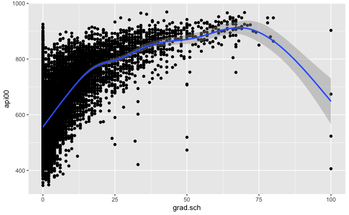

```r
MYDATA %>% ggplot(aes(x = grad.sch, y = api00)) +
  geom_point() +
  geom_smooth()
```

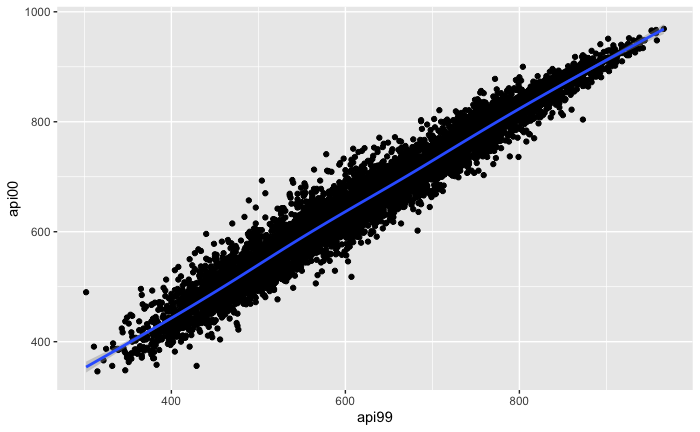

```r
MYDATA %>% ggplot(aes(x = api99, y = api00)) +
  geom_point() +
  geom_smooth()
```

As shown by the above plots, the relationship between `api00 ~ api99` is very linear whereas the relationship between `api00 ~ grad.sch` is less linear.